# Basic experiments workflow for simple epidemiological models

Anton Antonov

2020-04-13

# Introduction

The primary purpose of this notebook is to give a “stencil workflows” for simulations using the package ["ECMMon-R](https://github.com/antononcube/ECMMon-R), [AAr2].

We present two code workflows: one based on “low-level” package usage, the other based on (monadic) pipelines.

The model in this notebook – SEI2R – differs from [the classical SEIR model](https://en.wikipedia.org/wiki/Compartmental_models_in_epidemiology) with the following elements:

1. Two separate infected populations: one is “severely symptomatic”, the other is “normally symptomatic”
2. The monetary equivalent of lost productivity due to infected or died people is tracked

**Remark:** We consider the contagious disease propagation models as instances of the more general [System Dynamics (SD)](https://en.wikipedia.org/wiki/System_dynamics) models. We use SD terminology in this notebook.

**Remark:** The SEI2R model is a modification of the classic epidemic model SEIR, [Wk1, HH1].

**Remark:** The monadic pipelines in the notebook can be used for attempts to calibrate SEI2R with real data. (For example, data for the [2019–20 coronavirus outbreak](https://en.wikipedia.org/wiki/2019â20_coronavirus_outbreak), [WRI1].)

**Remark:** The repository “ECMMon-R”, [AAr2], has a [flexdashboard](https://github.com/antononcube/ECMMon-R/blob/master/flexdashboards/SEI2HR-flexdashboard.Rmd) for interactive experimentation with the package models. The flexdashboard can be easily developed further or changed in order to fit user’s needs.

# Workflow

# Install and load `ECMMon`

This notebook use the package `ECMMon-R`, [AAr2], which implements a software monad for rapid specification of Epidemiologic Compartmental Modeling (ECM) workflows.

Monad’s name is “ECMMon”, which stands for “**E**pidemiology **C**ompartmental **M**odeling **Mon**ad”.

```r
#devtools::install_github( "antononcube/ECMMon-R")
library(ECMMon)
library(magrittr)
library(dplyr)
library(tidyr)
library(ggplot2)
```

# Low-level code

## Getting the model code

Here we take the SEI2R model implemented in the package [“ECMMon-R”](https://github.com/antononcube/ECMMon-R), [AAr2]:

```r
model <- SEI2RModel( initialConditionsQ = TRUE, rateRulesQ = TRUE, birthsTermQ = FALSE )
```

The model object is a list with named elements:

```r
names(model)
```

```
[1] "Stocks"            "Rates"             "RHSFunction"       "InitialConditions" "RateRules"
```

Here are the stocks:

```r
as.data.frame(model$Stocks)
```

|  | model$Stocks |
| --- | --- |
| TPt | Total Population |
| SPt | Susceptible Population |
| EPt | Exposed Population |
| INSPt | Infected Normally Symptomatic Population |
| ISSPt | Infected Severely Symptomatic Population |
| RPt | Recovered Population |
| MLPt | Money of Lost Productivity |

Here are the rates:

```r
as.data.frame(model$Rates)
```

|  | model$Rates |
| --- | --- |
| TP0 | Initial value of Total Population |
| deathRateTP | Population death rate |
| deathRateINSP | Infected Normally Symptomatic Population death rate |
| deathRateISSP | Infected Severely Symptomatic Population death rate |
| contactRateINSP | Contact rate for the infected normally syptomatic population |
| contactRateISSP | Contact rate for the infected severely syptomatic population |
| sspf | Severely symptomatic population fraction |
| aip | Average infectious period |
| aincp | Average incubation period |
| lpcr | Lost productivity cost rate (per person per day) |

Here is the Right Hand Side (RHS) function used in calls of the function `ode` of the package “deSolve”, [KS1]:

```r
model$RHSFunction
```

```
function( time, state, parameters ) {
          with(as.list( c( state, parameters ) ),
               {

                 newlyInfectedTerm <- contactRateISSP / TP0 * SPt * ISSPt + contactRateINSP / TP0 * SPt * INSPt;

                 if( birthsTermQ ) {
                   dSPt <-  deathRateTP * TP0 - newlyInfectedTerm - deathRateTP * SPt
                 } else {
                   dSPt <-  - newlyInfectedTerm - deathRateTP * SPt
                 }

                 dEPt <- newlyInfectedTerm - (deathRateTP + (1 / aincp) ) * EPt

                 dINSPt <- (1 - sspf) * (1 / aincp) * EPt - (1 / aip) * INSPt - deathRateINSP * INSPt

                 dISSPt <- sspf * (1 / aincp) * EPt - (1 / aip) * ISSPt - deathRateISSP * ISSPt

                 dRPt <- (1 / aip) * (ISSPt + INSPt) - deathRateTP * RPt

                 dMLPt <- lpcr * ( INSPt + ISSPt + deathRateINSP * INSPt + deathRateISSP * ISSPt )

                 return( list( c( dSPt, dEPt, dINSPt, dISSPt, dRPt, dMLPt ) ) )
               }
          )
        }
<bytecode: 0x7f9b0c7c6c28>
<environment: 0x7f9b1bd36420>
```

Here are the initial conditions:

```r
as.data.frame(model$InitialConditions)
```

|  | model$InitialConditions |
| --- | --- |
| SPt | 99999 |
| EPt | 0 |
| INSPt | 0 |
| ISSPt | 1 |
| RPt | 0 |
| MLPt | 0 |

Here are the rate values:

```r
as.data.frame(model$RateRules)
```

|  | model$RateRules |
| --- | --- |
| TP0 | 1.000000e+05 |
| deathRateTP | 2.191780e-05 |
| deathRateINSP | 5.769231e-04 |
| deathRateISSP | 1.346154e-03 |
| aip | 2.600000e+01 |
| aincp | 6.000000e+00 |
| contactRateINSP | 5.600000e-01 |
| contactRateISSP | 5.600000e-01 |
| sspf | 2.000000e-01 |
| lpcr | 1.000000e+00 |

## Parameter changes

Here we change the initial condition for the stock Infected Severely Symptomatic Population (ISSP):

```r
model$InitialConditions["ISSPt"] <- 20
```

```r
model$RateRules["contactRateISSP"] <- 0.3
```

## Simulation

In this section we compute a simulation with model object described above. (Using [`deSolve::ode`](https://www.rdocumentation.org/packages/deSolve/versions/1.28/topics/ode).)

Here are the simulation times:

```r
times <- seq( 0, 365, 1)
```

Here we compute the simulation:

```r
sol <- deSolve::ode(y = model[["InitialConditions"]], times = times, func = model[["RHSFunction"]], parms = model[["RateRules"]], method = "rk4" )
```

Here we convert the matrix `sol` into a data frame:

```r
dfSol <- as.data.frame(sol)
colnames(dfSol) <- gsub( "time", "Time", colnames(dfSol) )
head(dfSol)
```

|  | Time | SPt | EPt | INSPt | ISSPt | RPt | MLPt |
| --- | --- | --- | --- | --- | --- | --- | --- |
| 1 | 0 | 99999.00 | 0.000000 | 0.000000 | 20.00000 | 0.0000000 | 0.00000 |
| 2 | 1 | 99990.85 | 5.490652 | 0.371590 | 19.31236 | 0.7601292 | 19.79009 |
| 3 | 2 | 99982.47 | 10.346636 | 1.399272 | 18.81907 | 1.5248987 | 39.70087 |
| 4 | 3 | 99973.48 | 15.031042 | 3.006817 | 18.49977 | 2.3248961 | 60.52824 |
| 5 | 4 | 99963.51 | 19.908535 | 5.174413 | 18.34827 | 3.1884137 | 83.00838 |
| 6 | 5 | 99952.18 | 25.289535 | 7.926710 | 18.36955 | 4.1438496 | 107.88024 |

**Remark:** We can see in the first row that ISSP starts with the initial condition we set.

## Visualization

Next we plot the solutions of the “non-money” stocks using the package “ggplot2” after we first convert the data frame `dfSol` into long form using the package “tydir”:

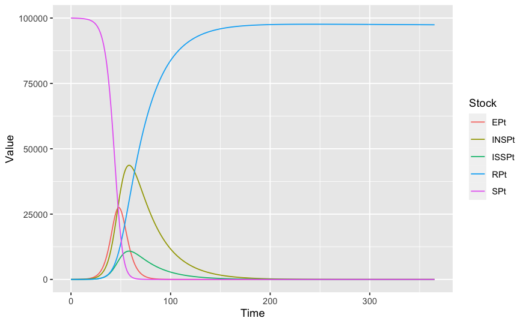

```r
dfSol %>%
  tidyr::pivot_longer( cols = colnames(dfSol)[-1], names_to = "Stock", values_to = "Value" ) %>%
  dplyr::filter( Stock != "MLPt" ) %>%
  ggplot2::ggplot( ) +
  ggplot2::geom_line( ggplot2::aes( x = Time, y = Value, color = Stock ) )
```

Here we plot the solutions histograms:

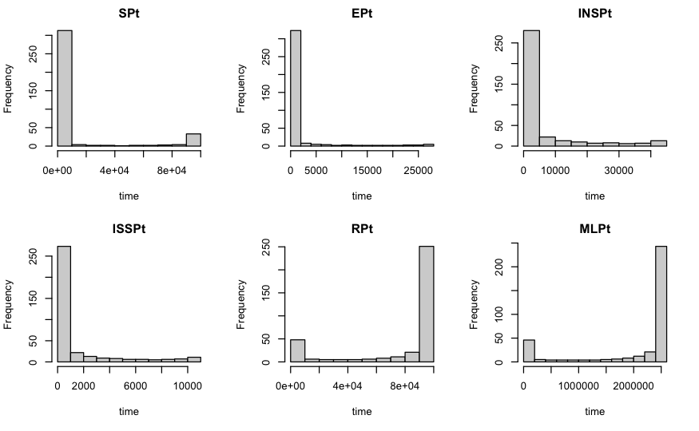

```r
hist(sol)
```

# Pipelines

Here is a pipeline that corresponds to the code in the previous section:

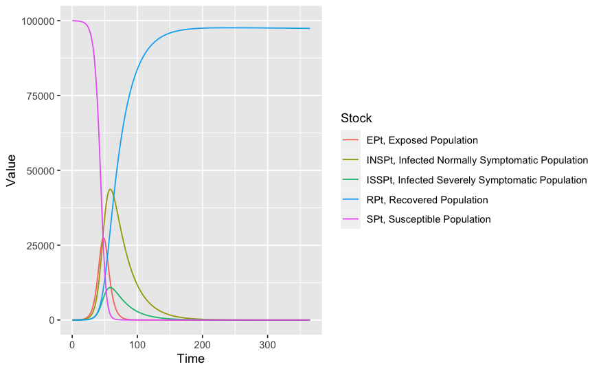

```r
ecmObj <-
  ECMMonUnit( SEI2RModel() ) %>%
  ECMMonAssignInitialConditions( initConds = c( "ISSPt" = 20 ) ) %>%
  ECMMonAssignRateValues(rateValues = c("contactRateISSP" = 0.3 ) ) %>%
  ECMMonSimulate( 365 ) %>%
  ECMMonPlotSolutions( stocksSpec = ".*Population" )
```

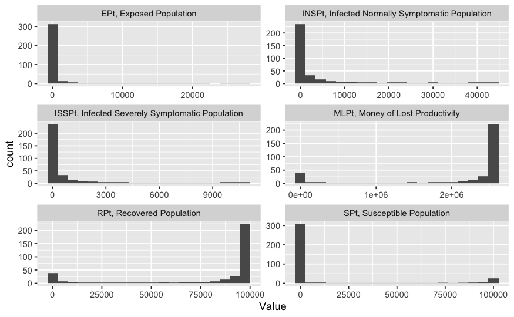

```r
ecmObj <-
  ecmObj %>%
  ECMMonPlotSolutionHistograms(bins=20)
```

Here we see the first rows of the solutions data frame (in the monad object):

```r
head(ecmObj %>% ECMMonTakeSolution)
```

|  | Time | SPt | EPt | INSPt | ISSPt | RPt | MLPt |
| --- | --- | --- | --- | --- | --- | --- | --- |
| 1 | 0 | 99999.00 | 0.000000 | 0.0000000 | 20.00000 | 0.0000000 | 0.00000 |
| 2 | 1 | 99990.85 | 5.491491 | 0.3713033 | 19.31229 | 0.7601687 | 19.79111 |
| 3 | 2 | 99982.47 | 10.347784 | 1.3989040 | 18.81897 | 1.5249552 | 39.70234 |
| 4 | 3 | 99973.48 | 15.032243 | 3.0064751 | 18.49968 | 2.3249596 | 60.52989 |
| 5 | 4 | 99963.51 | 19.909684 | 5.1741536 | 18.34821 | 3.1884814 | 83.01014 |
| 6 | 5 | 99952.18 | 25.290616 | 7.9265610 | 18.36951 | 4.1439230 | 107.88215 |

# Calibration with real data

It is important to calibrate these kind of models with real data, or at least to give a serious attempt to such a calibration. If the calibration is “too hard” or “impossible” that would indicate that the model is not that adequate. (If adequate at all.)

The calibration efforts can be (semi-)automated using special model-to-data goodness of fit functions and a minimization procedure. (See for example, [AA2].)

*(To be finished…)*

# References

## Articles

[Wk1] Wikipedia entry, [“Compartmental models in epidemiology”](https://en.wikipedia.org/wiki/Compartmental_models_in_epidemiology).

[HH1] Herbert W. Hethcote (2000). [“The Mathematics of Infectious Diseases”](http://leonidzhukov.net/hse/2014/socialnetworks/papers/2000SiamRev.pdf). SIAM Review. 42 (4): 599–653. Bibcode:2000SIAMR..42..599H. doi:10.1137/s0036144500371907.

[AA1] Anton Antonov, [“Coronavirus propagation modeling considerations”](https://github.com/antononcube/SystemModeling/blob/master/Projects/Coronavirus-propagation-dynamics/Documents/Coronavirus-propagation-modeling-considerations.md), (2020), [SystemModeling at GitHub](https://github.com/antononcube/SystemModeling).

[AA2] Anton Antonov, [Answer of “Model calibration with phase space data”](https://mathematica.stackexchange.com/a/190295/34008), (2019), [Mathematica StackExchange](https://mathematica.stackexchange.com).

## Repositories & packages

[WRI1] Wolfram Research, Inc., [“Epidemic Data for Novel Coronavirus COVID-19”](https://www.wolframcloud.com/obj/resourcesystem/published/DataRepository/resources/Epidemic-Data-for-Novel-Coronavirus-COVID-19), [WolframCloud](https://www.wolframcloud.com).

[KS1] Karline Soetaert et al, [“deSolve: Solvers for Initial Value Problems of Differential Equations (‘ODE’, ‘DAE’, ‘DDE’)”](https://cran.r-project.org/web/packages/deSolve/index.html), [CRAN](https://cran.r-project.org).

[AAr1] Anton Antonov, [Coronavirus propagation dynamics project](https://github.com/antononcube/SystemModeling/tree/master/Projects/Coronavirus-propagation-dynamics), (2020), [SystemModeling at GitHub](https://github.com/antononcube/SystemModeling).

[AAr2] Anton Antonov, [Epidemiology Compartmental Modeling Monad R package](https://github.com/antononcube/ECMMon-R), (2020), [ECMMon-R at GitHub](https://github.com/antononcube/ECMMon-R).

[AAp1] Anton Antonov, [“Epidemiology models Mathematica package”](https://github.com/antononcube/SystemModeling/blob/master/Projects/Coronavirus-propagation-dynamics/WL/EpidemiologyModels.m), (2020), [SystemModeling at GitHub](https://github.com/antononcube/SystemModeling).

[AAp2] Anton Antonov, [“Epidemiology models modifications Mathematica package”](https://github.com/antononcube/SystemModeling/blob/master/Projects/Coronavirus-propagation-dynamics/WL/EpidemiologyModelModifications.m), (2020), [SystemModeling at GitHub](https://github.com/antononcube/SystemModeling).

[AAp3] Anton Antonov, [“System dynamics interactive interfaces functions Mathematica package”](https://github.com/antononcube/SystemModeling/blob/master/WL/SystemDynamicsInteractiveInterfacesFunctions.m), (2020), [SystemModeling at GitHub](https://github.com/antononcube/SystemModeling).